# Week 8: Support Vector Machine

# Load packages

```r
library('caret')

# load the data set:

heart <- read.csv("heart_disease.csv", sep = ',', header = FALSE)
```

In the above line of code, we’re reading the dataset which is stored in a CSV format and that’s why we’ve used the read.csv function to read it from the specified path The ‘sep’ attribute indicates that the data is stored in a CSV or Comma Separated Version

```r
# Check the structure of our dataset

str(heart)
```

```
'data.frame':   297 obs. of  14 variables:
 $ V1 : num  63 67 67 37 41 56 62 57 63 53 ...
 $ V2 : num  1 1 1 1 0 1 0 0 1 1 ...
 $ V3 : num  1 4 4 3 2 2 4 4 4 4 ...
 $ V4 : num  145 160 120 130 130 120 140 120 130 140 ...
 $ V5 : num  233 286 229 250 204 236 268 354 254 203 ...
 $ V6 : num  1 0 0 0 0 0 0 0 0 1 ...
 $ V7 : num  2 2 2 0 2 0 2 0 2 2 ...
 $ V8 : num  150 108 129 187 172 178 160 163 147 155 ...
 $ V9 : num  0 1 1 0 0 0 0 1 0 1 ...
 $ V10: num  2.3 1.5 2.6 3.5 1.4 0.8 3.6 0.6 1.4 3.1 ...
 $ V11: num  3 2 2 3 1 1 3 1 2 3 ...
 $ V12: num  0 3 2 0 0 0 2 0 1 0 ...
 $ V13: num  6 3 7 3 3 3 3 3 7 7 ...
 $ V14: num  0 1 1 0 0 0 1 0 1 1 ...
```

Our next step is to split the data into training set and testing set, this is also called data splicing. We’ll be using the training set specifically for our model building and the testing set for evaluating the model:

# Split data into test / train

```r
intrain <- createDataPartition(y = heart$V14, p= 0.7, list = FALSE)
training <- heart[intrain,]
testing <- heart[-intrain,]
```

The caret package provides a method createDataPartition() which is basically for partitioning our data into train and test set.

We’ve passed 3 parameters to this createdatapartition() function:

The “y” parameter takes the value of variable according to which data needs to be partitioned. In our case, target variable is at V14, so we are passing heart$V14

The “p” parameter holds a decimal value in the range of 0-1. It’s to show the percentage of the split. We are using p=0.7. It means that data split should be done in 70:30 ratio. So, 70% of the data is used for training and the remaining 30% is for testing the model.

The “list” parameter is for whether to return a list or matrix. We are passing FALSE for not returning a list.

Now this createDataPartition() method is returning a matrix “intrain”. This intrain matrix has our training data set and we’re storing this in the ‘training’ variable and the rest of the data, i.e. the remaining 30% of the data is stored in the testing variable.

Next, for checking the dimensions of our training data frame and testing data frame, we can use these:

```r
dim(training)
```

```
[1] 208  14
```

```r
dim(testing)
```

```
[1] 89 14
```

Our next step is to clean the data, so if there are any missing values or inconsistent values, they have to be dealt with before we build the training model We’ll be using the anyNA() method, which checks for any null values:

```r
anyNA(heart)
```

```
[1] FALSE
```

on running this, we get the return values as false, which means that there are no missing values in our dataset. Next, we’re checking the summary of our data by using the summary() function

```r
summary(heart)
```

```
       V1              V2               V3              V4              V5              V6               V7               V8              V9
 Min.   :29.00   Min.   :0.0000   Min.   :1.000   Min.   : 94.0   Min.   :126.0   Min.   :0.0000   Min.   :0.0000   Min.   : 71.0   Min.   :0.0000
 1st Qu.:48.00   1st Qu.:0.0000   1st Qu.:3.000   1st Qu.:120.0   1st Qu.:211.0   1st Qu.:0.0000   1st Qu.:0.0000   1st Qu.:133.0   1st Qu.:0.0000
 Median :56.00   Median :1.0000   Median :3.000   Median :130.0   Median :243.0   Median :0.0000   Median :1.0000   Median :153.0   Median :0.0000
 Mean   :54.54   Mean   :0.6768   Mean   :3.158   Mean   :131.7   Mean   :247.4   Mean   :0.1448   Mean   :0.9966   Mean   :149.6   Mean   :0.3266
 3rd Qu.:61.00   3rd Qu.:1.0000   3rd Qu.:4.000   3rd Qu.:140.0   3rd Qu.:276.0   3rd Qu.:0.0000   3rd Qu.:2.0000   3rd Qu.:166.0   3rd Qu.:1.0000
 Max.   :77.00   Max.   :1.0000   Max.   :4.000   Max.   :200.0   Max.   :564.0   Max.   :1.0000   Max.   :2.0000   Max.   :202.0   Max.   :1.0000
      V10             V11             V12              V13             V14
 Min.   :0.000   Min.   :1.000   Min.   :0.0000   Min.   :3.000   Min.   :0.0000
 1st Qu.:0.000   1st Qu.:1.000   1st Qu.:0.0000   1st Qu.:3.000   1st Qu.:0.0000
 Median :0.800   Median :2.000   Median :0.0000   Median :3.000   Median :0.0000
 Mean   :1.056   Mean   :1.603   Mean   :0.6768   Mean   :4.731   Mean   :0.4613
 3rd Qu.:1.600   3rd Qu.:2.000   3rd Qu.:1.0000   3rd Qu.:7.000   3rd Qu.:1.0000
 Max.   :6.200   Max.   :3.000   Max.   :3.0000   Max.   :7.000   Max.   :1.0000
```

The output shows that the values of the various variables are not standardized. For example, the V14 variables, which is our target variable, it holds only 2 values, either 0 or 1. Instead, this should be a categorical variable. To convert these to categorical variables, we need to factorize them:

# Change into categorical variables

```r
training[["V14"]] = factor(training[["V14"]])
```

Our next step is to train our model.

Before we train our model, we’ll first implement the trainControl() method. This will control all the computational overheads so that we can use the train() function provided by the caret package. The training method will train our data on different algorithms.

traincontrol() method:

```r
trctrl <- trainControl(method = "repeatedcv", number = 10, repeats = 3)
```

The trainControl() method here, is taking 3 parameters.

The “method” parameter defines the resampling method, in this demo we’ll be using the repeatedcv or the repeated cross-validation method.

The next parameter is the “number”, this basically holds the number of resampling iterations.

The “repeats” parameter contains the sets to compute for our repeated cross- validation. We are using setting number =10 and repeats =3

This trainControl() method returns a list. We are going to pass this on our train() method.

```r
svm_Linear <- train(V14 ~., data = training, method =
"svmLinear",trControl=trctrl,preProcess = c("center", "scale"),tuneLength
= 10)
```

The train() method should be passed with “method” parameter as “svmLinear”. We are passing our target variable V14. The “V14~.” denotes a formula for using all attributes in our classifier and V14 as the target variable. The “trControl” parameter should be passed with results from our trianControl() method. The “preProcess” parameter is for preprocessing our training data

We are passing 2 values in our “pre-process” parameter “center” & “scale”.

```r
svm_Linear
```

```
Support Vector Machines with Linear Kernel

208 samples
 13 predictor
  2 classes: '0', '1'

Pre-processing: centered (13), scaled (13)
Resampling: Cross-Validated (10 fold, repeated 3 times)
Summary of sample sizes: 187, 187, 187, 187, 188, 187, ...
Resampling results:

  Accuracy   Kappa
  0.8298413  0.6466175

Tuning parameter 'C' was held constant at a value of 1
```

It’s a linear model therefore, it just tested at value “C” =1.

Now, our model is trained with C value as 1. We are ready to predict classes for our test set. We can use predict() method. The caret package provides predict() method for predicting results. We are passing 2 arguments. Its first parameter is our trained model and second parameter “newdata” holds our testing data frame. The predict() method returns a list, we are saving it in a test_pred variable.

```r
test_pred <- predict(svm_Linear, newdata = testing)

test_pred
```

```
 [1] 1 1 0 1 0 1 0 0 1 1 1 0 0 0 0 1 1 1 1 1 0 0 1 0 0 1 0 1 1 0 1 1 0 1 0 0 0 1 1 0 1 0 0 1 1 1 0 1 1 1 1 1 0 1 0 0 0 0 1 0 0 1 0 1 0 1 1 1 0 0 1 1 1 0 0 1 1 1
[79] 0 0 0 0 1 1 1 0 1 1 0
Levels: 0 1
```

Now let’s check the accuracy of our model. We’re going to use the confusion matrix to predict the accuracy:

```r
confusionMatrix(table(test_pred, testing$V14))
```

```
Confusion Matrix and Statistics


test_pred  0  1
        0 33  8
        1  7 41

               Accuracy : 0.8315
                 95% CI : (0.7373, 0.9025)
    No Information Rate : 0.5506
    P-Value [Acc > NIR] : 2.042e-08

                  Kappa : 0.6602

 Mcnemar's Test P-Value : 1

            Sensitivity : 0.8250
            Specificity : 0.8367
         Pos Pred Value : 0.8049
         Neg Pred Value : 0.8542
             Prevalence : 0.4494
         Detection Rate : 0.3708
   Detection Prevalence : 0.4607
      Balanced Accuracy : 0.8309

       'Positive' Class : 0
```

By following the above procedure, we can build our svmLinear classifier.

We can also do some customization for selecting C value(Cost) in Linear classifier. This can be done by inputting values in grid search. The next code snippet will show you, building & tuning of an SVM classifier with different values of C.

We are going to put some values of C using expand.grid() into “grid” dataframe. Next step is to use this dataframe for testing our classifier at specific C values. It needs to be put in train() method with tuneGrid parameter.

```r
grid <- expand.grid(C = c(0,0.01, 0.05, 0.1, 0.25, 0.5, 0.75, 1, 1.25,
1.5, 1.75, 2,5))

svm_Linear_Grid <- train(V14 ~., data = training, method = "svmLinear",trControl=trctrl,preProcess = c("center", "scale"),tuneGrid = grid,tuneLength = 10)
```

[output not shown]

[output cut: 39 more lines]

[output not shown]

```r
svm_Linear_Grid
```

```
Support Vector Machines with Linear Kernel

208 samples
 13 predictor
  2 classes: '0', '1'

Pre-processing: centered (13), scaled (13)
Resampling: Cross-Validated (10 fold, repeated 3 times)
Summary of sample sizes: 188, 187, 187, 187, 187, 187, ...
Resampling results across tuning parameters:

  C     Accuracy   Kappa
  0.00        NaN        NaN
  0.01  0.8445238  0.6724666
  0.05  0.8365079  0.6594806
  0.10  0.8316667  0.6502454
  0.25  0.8269048  0.6418003
  0.50  0.8221429  0.6322437
  0.75  0.8205556  0.6291451
  1.00  0.8204762  0.6284134
  1.25  0.8188889  0.6253864
  1.50  0.8204762  0.6282452
  1.75  0.8204762  0.6282452
  2.00  0.8204762  0.6282452
  5.00  0.8204762  0.6282452

Accuracy was used to select the optimal model using the largest value.
The final value used for the model was C = 0.01.
```

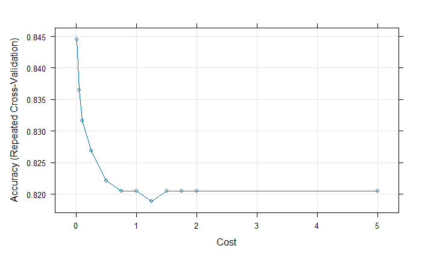

```r
plot(svm_Linear_Grid)
```

```r
test_pred_grid <- predict(svm_Linear_Grid, newdata = testing)

test_pred_grid
```

```
 [1] 1 0 0 1 0 1 0 0 1 1 1 0 0 0 0 0 1 1 1 1 0 0 1 0 0 1 0 1 1 0 1 1 0 1 0 0 0 1 1 0 1 0 0 1 1 1 0 1 1 1 1 1 0 1 0 0 0 0 1 0 0 1 0 1 0 1 1 1 0 0 1 1 1 0 0 1 1 1
[79] 0 0 0 0 0 1 1 0 1 1 0
Levels: 0 1
```

Let’s check its accuracy using confusion -matrix.

```r
confusionMatrix(table(test_pred_grid, testing$V14))
```

```
Confusion Matrix and Statistics


test_pred_grid  0  1
             0 35  9
             1  5 40

               Accuracy : 0.8427
                 95% CI : (0.7502, 0.9112)
    No Information Rate : 0.5506
    P-Value [Acc > NIR] : 4.883e-09

                  Kappa : 0.685

 Mcnemar's Test P-Value : 0.4227

            Sensitivity : 0.8750
            Specificity : 0.8163
         Pos Pred Value : 0.7955
         Neg Pred Value : 0.8889
             Prevalence : 0.4494
         Detection Rate : 0.3933
   Detection Prevalence : 0.4944
      Balanced Accuracy : 0.8457

       'Positive' Class : 0
```

The results of the confusion matrix show that this time the accuracy on the test set is 84.27%, which is more accurate than our previous result.

Resources • https://www.edureka.co/ • https://www.kaggle.com/ • https://www.youtube.com/watch?v=Y6RRHw9uN9o